# Big Data Analytics using R - Coursework 1

JP Sainsbury

15 October 2017

## 1. (a) Suppose you ask a group of 10 students at Birkbeck College how many brothers and sisters they have. The number obtained are as follows:2 3 0 5 2 1 1 0 3 3 Find the following measures of central tendency: (i) the mean, (ii) the median and (iii) the mode.

Sample

```r
n = 10
x = c(2, 3, 0, 5, 2, 1, 1, 0, 3, 3)
```

1. Mean

```r
mean(x)
```

```
## [1] 2
```

(ii)Meadian

```r
median(x)
```

```
## [1] 2
```

(iii)Mode

```r
names(sort(-table(x)))[1]
```

```
## [1] "3"
```

## Find the following measures of spread:

4. the variance

```r
var(x)
```

```
## [1] 2.444444
```

22. the standard divation

```r
sd(x)
```

```
## [1] 1.563472
```

## (b) Suppose these 10 students have the following age: 23 25 18 45 30 21 22 19 29 35

1. Find the covariance and correlation between the number of siblings and their age.
2. Is there a positive or negative or no correlation between the two?
3. Is there causation between the two? Justify your answers.

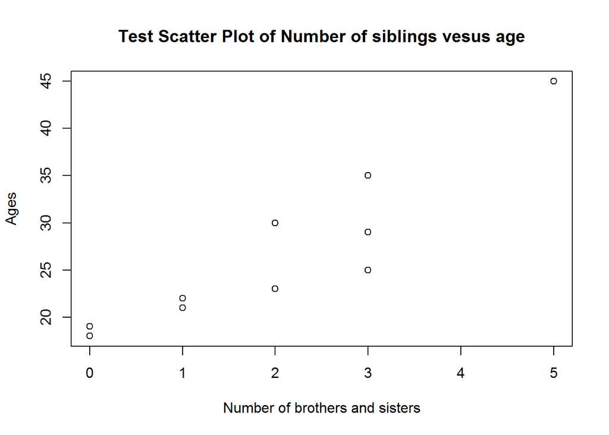

```r
y = c(23, 25, 18, 45, 30, 21, 22, 19, 29, 35)
plot(x,y, xlab="Number of brothers and sisters", ylab="Ages", main="Test Scatter Plot of Number of siblings vesus age")
```

1. Covariance

```r
cov(x,y)
```

```
## [1] 11.88889
```

& Correlation

```r
cor(x,y)
```

```
## [1] 0.9116971
```

2. There is a positive correlation between the two.
3. The older generation are more likely to have more brothers and sisters. The plot clearly shows the positive correlation between the two.

## 2 Getting familiar with R

1. Load library

```r
library(MASS)
```

Number of rows and columns.

The rows represent the cases, the cases here are suburbs of Boston. The columns represent the variables.

```r
nrow(Boston)
```

```
## [1] 506
```

```r
ncol(Boston)
```

```
## [1] 14
```

Columns also known as the variables contain 14 atributes.They are:

```r
names(Boston)
```

```
##  [1] "crim"    "zn"      "indus"   "chas"    "nox"     "rm"      "age"
##  [8] "dis"     "rad"     "tax"     "ptratio" "black"   "lstat"   "medv"
```

## Some pairwise scatterplots

2. The below scatterplot displays a positive correlation between the number of rooms per dwelling and the median value. The more rooms a property has positivley influences the value of the house. The more rooms the dwelling has the higher the value of the house.

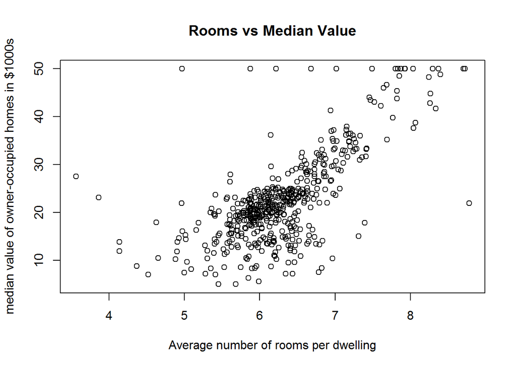

```r
plot(Boston$rm , Boston$medv, xlab="Average number of rooms per dwelling", ylab="median value of owner-occupied homes in $1000s", main = "Rooms vs Median Value")
```

```r
cor(Boston$rm , Boston$medv, )
```

```
## [1] 0.6953599
```

The below scatterplot displays a positive correlation between the property tax rate and Nitrogen oxides concentration. This idicates the higher the nitrogen oxides concentraction the more property tax paid. This leads me to believe house prices and nitrogen oxides positivly influence each other. It is known property prices are higher in the innercitys, demand for houses, population, traffic and polution are also concentrated in the inner citys. The scotterplot below supports this hypothesis.

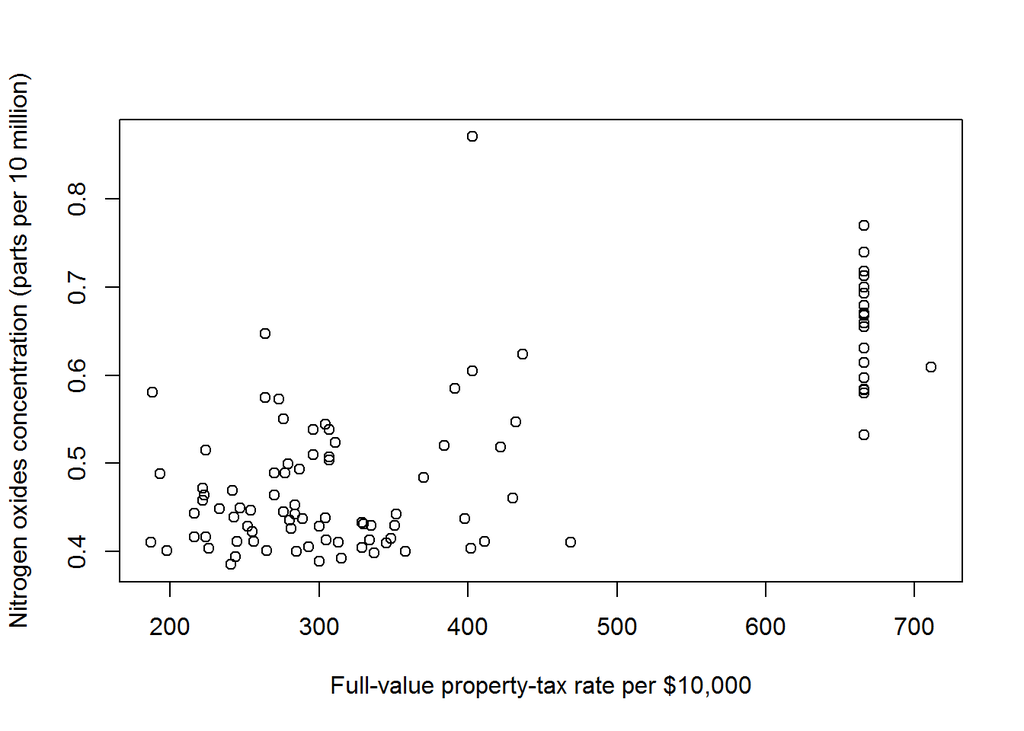

```r
plot(Boston$tax , Boston$nox, xlab="Full-value property-tax rate per $10,000", ylab="Nitrogen oxides concentration (parts per 10 million)" )
```

```r
 cor(Boston$tax , Boston$nox, )
```

```
## [1] 0.6680232
```

3. Are any of the predictors associated with per capita crime rate? If so, explain the relationship

```r
library(xtable)
table(cor(Boston$crim,Boston))
```

```
##
##  -0.388304608586812  -0.385063941994224  -0.379670086951024
##                   1                   1                   1
##  -0.219246702862514  -0.200469219662547 -0.0558915822222415
##                   1                   1                   1
##    0.28994557927952   0.352734250901364   0.406583411406259
##                   1                   1                   1
##   0.420971711392456   0.455621479447946   0.582764312032585
##                   1                   1                   1
##   0.625505145262602                   1
##                   1                   1
```

```r
newobject<-xtable(cor(Boston$crim,Boston))
capture.output( print(newobject, print.gap=3))
```

[output not shown]

Lets order the results

```r
sort(cor(Boston$crim,Boston),decreasing = TRUE)
```

```
##  [1]  1.00000000  0.62550515  0.58276431  0.45562148  0.42097171
##  [6]  0.40658341  0.35273425  0.28994558 -0.05589158 -0.20046922
## [11] -0.21924670 -0.37967009 -0.38506394 -0.38830461
```

Lets pull out the strongest relationship

```r
sort(cor(Boston$crim,Boston),decreasing = TRUE)[2]
```

```
## [1] 0.6255051
```

Index of accessibility has the strongest relationship with per capita crime rate. The easier the access to a particular area has a positive correlation on crime rate. The easier it is to access an area, the more lickly it is to have criminal activities take place there.

Do any of the suburbs of Boston appear to have particularly high crime rates? Tax rates? Pupil-?-teacher ratios? Comment on the range of each predictor.

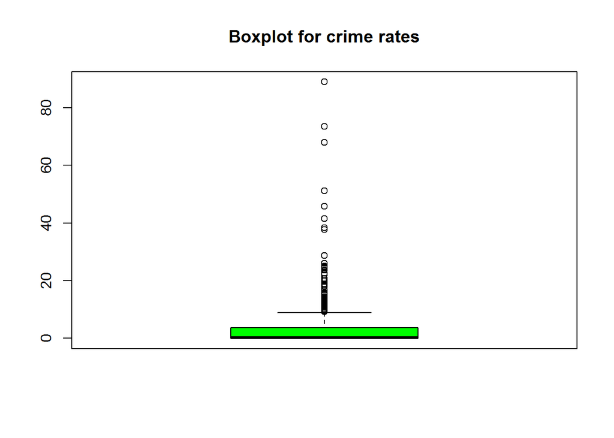

```r
boxplot(Boston$crim,col=c("green"), names=c("Crime Boxplot"), main="Boxplot for crime rates")
```

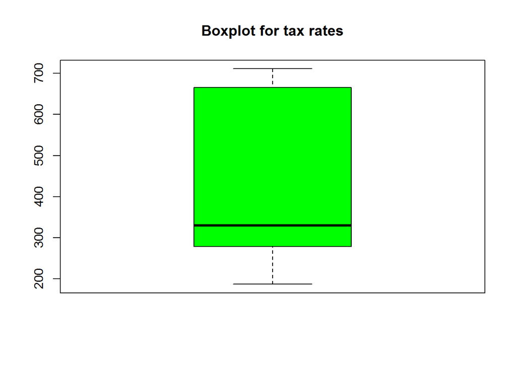

```r
boxplot(Boston$tax,col=c("green"), names=c("Tax Boxplot"), main="Boxplot for tax rates")
```

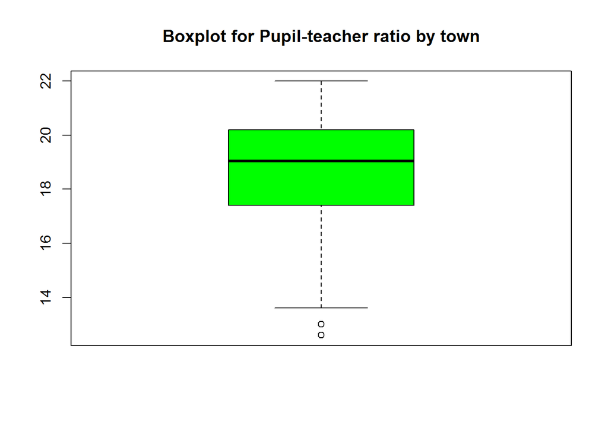

```r
boxplot(Boston$ptratio,col=c("green"), names=c("Pupil-teacher ratio by town"), main="Boxplot for Pupil-teacher ratio by town")
```

5. How many of the suburbs in this data set bound the Charles river?

```r
table(Boston$chas)
```

```
##
##   0   1
## 471  35
```

```r
sum(Boston$chas)
```

```
## [1] 35
```

6. What is the median pupil-?-teacher ratio among the towns in this data set?

```r
median(Boston$ptratio[Boston$chas=="1"])
```

```
## [1] 17.6
```

7. Which suburb of Boston has lowest median value of owner occupied homes? What are the values of the other predictors for that suburb, and how do those values compare to the overall ranges for those predictors? Comment on your findings.

```r
#Row 399 has the lowest median value of owner occupied homes
#399 its other metrics are:
head(Boston[order(Boston$medv),],1)
```

```
##        crim zn indus chas   nox    rm age    dis rad tax ptratio black
## 399 38.3518  0  18.1    0 0.693 5.453 100 1.4896  24 666    20.2 396.9
##     lstat medv
## 399 30.59    5
```

```r
set.seed(1)
x = rnorm(100,0,1)
```

```r
eps = rnorm(100,0,0.5)
```

MAking the prediction of Y on the basis X=x

```r
y= -1 + (0.5 * x) + eps
Y=y
```

Making the prediction of y on the basis Y=y

```r
length(y)
```

```
## [1] 100
```

Beta zero is equal to the intercept -1. Beta 1 is equal to the slope 0.5. Yes this is a linear model.

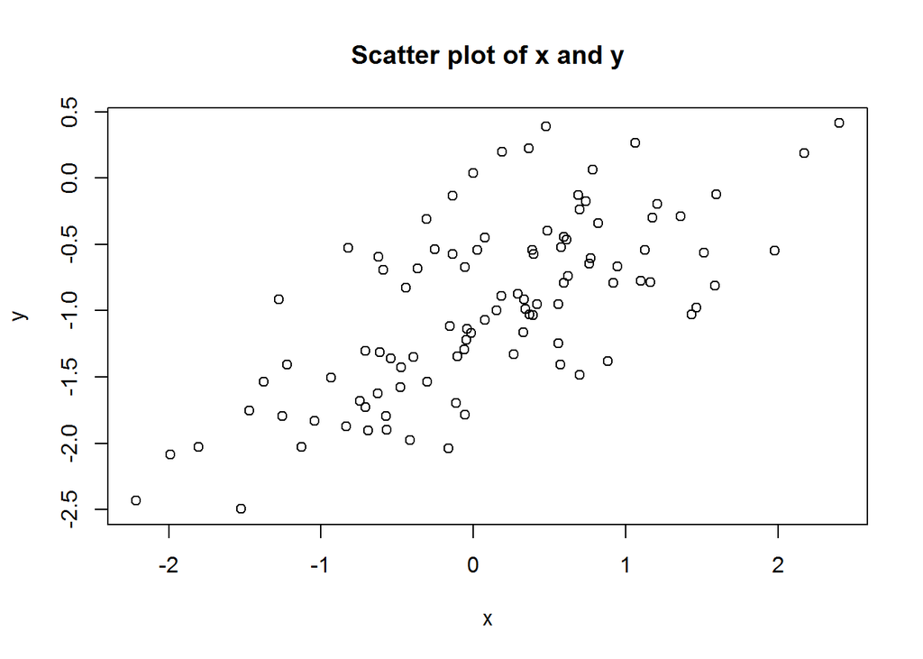

```r
plot(x,y,main = "Scatter plot of x and y", xlab = "x", ylab= "y")
```

There is a positive corelation between x and y.